# SNP panel

##### This is a script for finding an optimized SNP panel for iranian population based on iranome Dataset

`r`r library(parallel) library(‘UpSetR’) ir= readRDS(/home/delaram/iranome/chromosomes/cleanIranome.rds) head(ir)

|  | chrom | pos | HGVSc | HGVSp | allele_count | allele_freq | allele_num | alt | category | gene_name | genes | het_count | hom_count | major_consequence | ref | rsid | site_quality | variant_id | D2.5 | D7.5 | D12.5 | D17.5 | D22.5 | D27.5 | D32.5 | D37.5 | D42.5 | D47.5 | D52.5 | … |
| --- | --- | --- | --- | --- | --- | --- | --- | --- | --- | --- | --- | --- | --- | --- | --- | --- | --- | --- | --- | --- | --- | --- | --- | --- | --- | --- | --- | --- | --- | --- |
| 1 | 1 | 12783 |  |  | 243 | 0.532895000 | 456 | A | other_variant | DDX11L1 |  | 77 | 83 | Not Set | G | rs62635284 | 11653.70 | 1-12783-G-A | 495 | 0 | 87 | 0 | 65 | 0 | 71 | 0 | 42 | 0 | 21 | … |
| 2 | 1 | 12807 |  |  | 9 | 0.013432800 | 670 | T | other_variant | DDX11L1 |  | 9 | 0 | Not Set | C | rs62635285 | 253.33 | 1-12807-C-T | 455 | 74 | 0 | 74 | 0 | 50 | 47 | 0 | 46 | 0 | 21 | … |
| 3 | 1 | 12839 |  |  | 8 | 0.009732360 | 822 | C | other_variant | DDX11L1 |  | 6 | 1 | Not Set | G | rs747124606 | 144.63 | 1-12839-G-C | 384 | 109 | 49 | 55 | 0 | 51 | 39 | 22 | 26 | 0 | 20 | … |
| 4 | 1 | 12882 |  |  | 15 | 0.013966500 | 1074 | G | other_variant | DDX11L1 |  | 15 | 0 | Not Set | C | rs879918139 | 325.57 | 1-12882-C-G | 386 | 64 | 88 | 43 | 63 | 32 | 39 | 13 | 21 | 12 | 15 | … |
| 5 | 1 | 13079 |  |  | 10 | 0.006476680 | 1544 | G | other_variant | DDX11L1 |  | 10 | 0 | Not Set | C | rs78890234 | 896.00 | 1-13079-C-G | 74 | 60 | 49 | 110 | 84 | 100 | 205 | 61 | 14 | 11 | 9 | … |
| 6 | 1 | 13080 |  |  | 1 | 0.000647668 | 1544 | _ | other_variant | DDX11L1 |  | 1 | 0 | Not Set | GACA |  | 896.00 | 1-13080-GACA-_ | 74 | 60 | 49 | 110 | 84 | 100 | 205 | 61 | 14 | 11 | 9 | … |

loading the packages and the cleaned iranome dataset. The code for cleaning iranome is in another file

D stands for depth and Q stands for genotype quality. The histograms for Depth and qenotyping quality in the [iranome website](http://www.iranome.com/variant/1-12783-G-A) (all individuals section)are presented as multiple columns in the table.

`r`r ir$remove = (ir$hetFreq_Arab > 1 | ir$hetFreq_Azeri>1 | ir$hetFreq_Baloch>1 | ir$hetFreq_Kurd>1 | ir$hetFreq_Lur>1| ir$hetFreq_Persian>1| ir$`hetFreq_Persian Gulf Islander`>1 | ir$hetFreq_Turkmen>1) head(subset(ir, remove))

|  | chrom | pos | HGVSc | HGVSp | allele_count | allele_freq | allele_num | alt | category | gene_name | genes | het_count | hom_count | major_consequence | ref | rsid | site_quality | variant_id | D2.5 | D7.5 | D12.5 | D17.5 | D22.5 | D27.5 | D32.5 | D37.5 | D42.5 | D47.5 | D52.5 | … |
| --- | --- | --- | --- | --- | --- | --- | --- | --- | --- | --- | --- | --- | --- | --- | --- | --- | --- | --- | --- | --- | --- | --- | --- | --- | --- | --- | --- | --- | --- | --- |
| 12886 | 1 | 7289606 | c.303-19945delT |  | 3 | 0.428571 | 7 | _ | other_variant | CAMTA1 |  | 3 | 0 | intron_variant | T |  | 74302.6 | 1-7289606-T-_ | 148 | 131 | 123 | 226 | 69 | 47 | 34 | 9 | 7 | 2 | 0 | … |
| 12889 | 1 | 7289606 | c.303-19945T>A |  | 8 | 0.666667 | 12 | A | other_variant | CAMTA1 |  | 2 | 3 | intron_variant | T |  | 74302.6 | 1-7289606-T-A | 148 | 131 | 123 | 226 | 69 | 47 | 34 | 9 | 7 | 2 | 0 | … |
| 12892 | 1 | 7289606 | c.303-19945T>G |  | 681 | 0.994161 | 685 | G | other_variant | CAMTA1 |  | 3 | 339 | intron_variant | T | rs6659573 | 74302.6 | 1-7289606-T-G | 148 | 131 | 123 | 226 | 69 | 47 | 34 | 9 | 7 | 2 | 0 | … |
| 21895 | 1 | 15769877 | c.357-38_357-37insC |  | 1599 | 1.000000 | 1599 | C | other_variant | CTRC |  | 1 | 799 | intron_variant | _ | rs35149641,rs397730661 | 893416.0 | 1-15769877-_-C | 35 | 251 | 307 | 101 | 52 | 29 | 17 | 4 | 1 | 2 | 0 | … |
| 21897 | 1 | 15769877 | c.357-38_357-37insT |  | 1 | 1.000000 | 1 | T | other_variant | CTRC |  | 1 | 0 | intron_variant | _ |  | 893416.0 | 1-15769877-_-T | 35 | 251 | 307 | 101 | 52 | 29 | 17 | 4 | 1 | 2 | 0 | … |
| 26290 | 1 | 17085165 | , | , | 1466 | 0.963206 | 1522 | C | other_variant | CROCC |  | 118 | 674 | Not Set | G | rs2490828 | 1742020.0 | 1-17085165-G-C | 245 | 268 | 123 | 66 | 39 | 25 | 9 | 12 | 5 | 1 | 3 | … |

Some positions’ heterozygous frequency is higher than 1, these positions are labeled ‘true’ in an *remove* column

[figure not shown]

`r`r an.cut = an.sorted[round(length(an.sorted)*0.05)] #736 print(paste0(‘depth cut-off:’,d.cut, ‘quality cut-off:’, q.cut, ‘allele number cut-off:’,an.cut ))

```
[1] \depth cut-off: 103 quality cut-off: 370 allele number cut-off: 736\
```

`r`r nrow(ir) # before filter

[output not shown]

```
[1] 18787
```

Some basic filters are applied to the data.

`r`r head(HS)

```
[1] 0.4299378 0.4764875 0.4663308 0.4677962 0.4828263 0.4366653
```

P.A = P(A) = P(AA) + 0.5xP(Aa)

`r`r phat <- (sum(ir[,83:90])*2 + sum(ir[,75:82]))/sum(ir[,67:74]) # (homs*2+hets)/anc HT <- 2 * phat * (1-phat) ir$HI <- HI ir$F.IS <- (HS-HI)/HS ir$F.ST <- (HT-HS)/HT ir$F.IT <- (HT-HI)/HT head(ir)

|  | chrom | pos | HGVSc | HGVSp | allele_count | allele_freq | allele_num | alt | category | gene_name | genes | het_count | hom_count | major_consequence | ref | rsid | site_quality | variant_id | D2.5 | D7.5 | D12.5 | D17.5 | D22.5 | D27.5 | D32.5 | D37.5 | D42.5 | D47.5 | D52.5 | … |
| --- | --- | --- | --- | --- | --- | --- | --- | --- | --- | --- | --- | --- | --- | --- | --- | --- | --- | --- | --- | --- | --- | --- | --- | --- | --- | --- | --- | --- | --- | --- |
| 220 | 1 | 69897 | c.807T>C | p.Ser269= | 194 | 0.587879 | 330 | C | synonymous_variant | OR4F5 |  | 22 | 86 | synonymous_variant | T | rs200676709 | 10424.2 | 1-69897-T-C | 598 | 63 | 49 | 0 | 29 | 28 | 0 | 14 | 5 | 0 | 6 | … |
| 762 | 1 | 881627 | c.1843C>T | p.Leu615= | 899 | 0.561875 | 1600 | A | synonymous_variant | NOC2L |  | 361 | 269 | synonymous_variant | G | rs2272757 | 699074.0 | 1-881627-G-A | 12 | 34 | 203 | 199 | 205 | 95 | 33 | 11 | 6 | 1 | 0 | … |
| 1217 | 1 | 909073 | c.1590+53C>T |  | 825 | 0.519521 | 1588 | T | other_variant | PLEKHN1 |  | 371 | 227 | intron_variant | C | rs3892467 | 259722.0 | 1-909073-C-T | 58 | 168 | 235 | 116 | 96 | 59 | 38 | 17 | 5 | 1 | 5 | … |
| 1252 | 1 | 912049 | c.1868-45A>G |  | 856 | 0.549422 | 1558 | C | other_variant | C1orf170 |  | 320 | 268 | intron_variant | T | rs7367995 | 237251.0 | 1-912049-T-C | 69 | 282 | 253 | 92 | 40 | 32 | 18 | 4 | 2 | 5 | 1 | … |
| 1289 | 1 | 914940 | c.1188A>G | p.Ala396= | 937 | 0.586358 | 1598 | C | synonymous_variant | C1orf170 |  | 377 | 280 | synonymous_variant | T | rs13303033 | 1391480.0 | 1-914940-T-C | 30 | 67 | 114 | 130 | 153 | 134 | 94 | 44 | 20 | 5 | 7 | … |
| 1480 | 1 | 977203 | c.1177+121G>C |  | 187 | 0.540462 | 346 | C | other_variant | AGRN |  | 7 | 90 | intron_variant | G | rs3121552 | 52199.1 | 1-977203-G-C | 262 | 113 | 140 | 43 | 89 | 34 | 54 | 18 | 21 | 9 | 10 | … |

Calculating phat and heterozygisity and F indices

`r`r ir$dis=0 chr <- split( ir , f = ir$chrom ) dis.l = lapply(chr, function(i) sapply(1:nrow(i), function(j) (i[j+1,‘pos’]-i[j,‘pos’]) ))  
chr.temp = mapply(function(i,x) chr[[i]]$dis <<- x, seq(length(chr)), dis.l) ir <- do.call(rbind, chr)

This is a filter based on SNP distances

`r`r d.cut = 103 q.cut=370 an.cut=736 f.cut = 0.06  
h.cut.low=0 h.cut.up = 0.4 dis.cut=1e5 l = list(subset(ir,Dsum>d.cut),subset(ir,Qsum>q.cut),subset(ir,allele_num>an.cut), subset(ir,F.ST<f.cut),subset(ir,HI<h.cut.up&HI>h.cut.low),subset(ir,dis>dis.cut)) #

Setting the filter values. Sesitivity analysis > better ignore distance at first and check it at last *l* is a list of tables that in each of them a filter has been applied to the data.

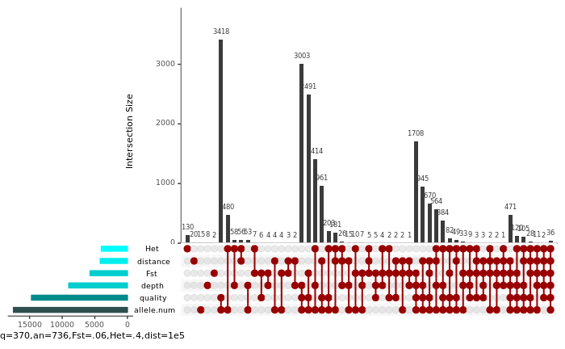

`r`r length(unique(sapply(1:nrow(ir2), function(i) paste(ir2[i,]$chrom,ir2[i,]$pos,sep = ’_’,collapse = NULL))))

```
[1] 2328
```

This is another criteria for filtering